# Final Report

Valeriia Ladyhina & Semyon Kupriyanov

2022-05-21

# Introduction

*This R Markdown is part of bigger pipeline on analysis of RNA seq data obtained in experiment on effects of different concentrations of antibiotic novobiocin on gene expression in **Salmonella enterica subsp. enterica serovar Typhimurium str. 14028S**. Analysis was performed on publicly available transciptomics data that can be found **here**.*

# Installation of required packages

*This part of pipeline includes few different packages, that have been installed on your computer, namely: **DESeq2, dplyr, ggplot2, gplots,clusterProfiler, WGCNA, knitr, KEGGREST,stringr**.*

# DESeq2 analysis

*For this analysis we used two files: **transcript_count_matrix.csv**, obtained during previous steps of snalemake pipeline based on StringTie and **pheno.csv** - file that describes our experimental data.*

*Next step is normalization of counts and saving of the result into file **norm-matrix-deseq2.txt***

*PCA analysis*

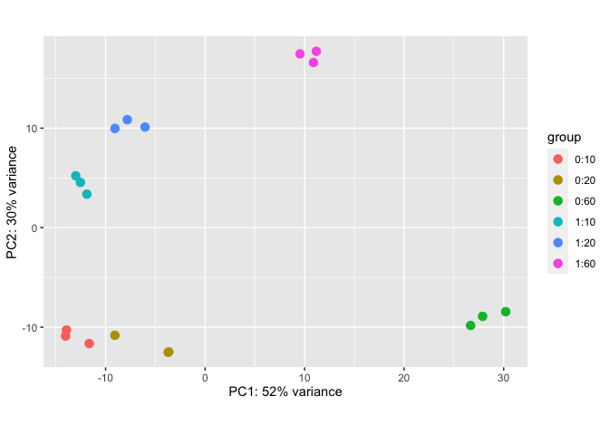

*At this step we are searching for significant genes*

*Volcano plot*

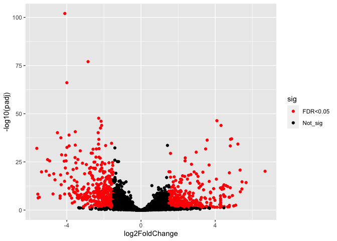

*DEG heatmap*

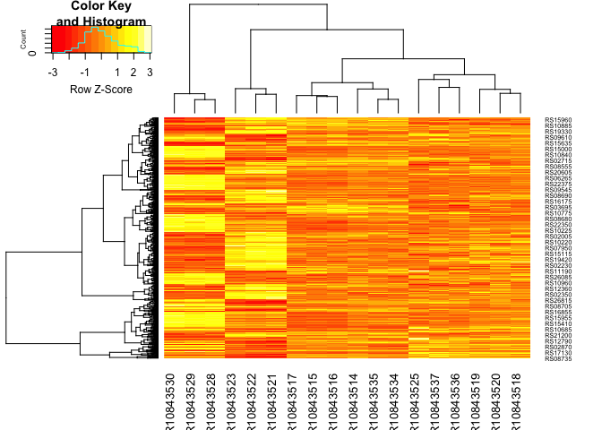

*Negative and positive DEG were saved in files **negative_deg.txt** and **positive_deg.txt** respectively.*

# KEGG enrichment analysis

*Negative DEG*

|  | ID | Description | GeneRatio | BgRatio | pvalue | p.adjust | qvalue | geneID | Count |
| --- | --- | --- | --- | --- | --- | --- | --- | --- | --- |
| seo00190 | seo00190 | Oxidative phosphorylation | 17/183 | 45/1749 | 0.0000008 | 0.0000250 | 0.0000210 | STM14_0422/STM14_0423/STM14_0519/STM14_0520/STM14_0521/STM14_0522/STM14_0861/STM14_0862/STM14_0863/STM14_1385/STM14_2857/STM14_4660/STM14_4661/STM14_4662/STM14_4663/STM14_4665/STM14_4666 | 17 |
| seo02040 | seo02040 | Flagellar assembly | 17/183 | 45/1749 | 0.0000008 | 0.0000250 | 0.0000210 | STM14_1345/STM14_1346/STM14_1347/STM14_1348/STM14_1349/STM14_1350/STM14_1351/STM14_1352/STM14_1353/STM14_2326/STM14_2373/STM14_2391/STM14_2393/STM14_2394/STM14_2395/STM14_2398/STM14_3888 | 17 |
| seo00010 | seo00010 | Glycolysis / Gluconeogenesis | 13/183 | 43/1749 | 0.0002556 | 0.0051129 | 0.0043056 | STM14_0184/STM14_1377/STM14_1565/STM14_1672/STM14_1891/STM14_1968/STM14_1995/STM14_2113/STM14_2642/STM14_2991/STM14_4438/STM14_4885/STM14_5383 | 13 |
| seo02030 | seo02030 | Bacterial chemotaxis | 8/183 | 23/1749 | 0.0015181 | 0.0227708 | 0.0191754 | STM14_2330/STM14_2331/STM14_2332/STM14_2333/STM14_2391/STM14_2398/STM14_4375/STM14_5085 | 8 |
| seo00500 | seo00500 | Starch and sucrose metabolism | 10/183 | 36/1749 | 0.0027534 | 0.0330407 | 0.0278238 | STM14_1595/STM14_1596/STM14_1881/STM14_1882/STM14_1883/STM14_2118/STM14_2172/STM14_2345/STM14_2346/STM14_2991 | 10 |

*Positive DEG*

|  | ID | Description | GeneRatio | BgRatio | pvalue | p.adjust | qvalue | geneID | Count |
| --- | --- | --- | --- | --- | --- | --- | --- | --- | --- |
| seo00660 | seo00660 | C5-Branched dibasic acid metabolism | 7/83 | 16/1749 | 0.0000034 | 0.0001944 | 0.0001831 | STM14_0131/STM14_0132/STM14_0133/STM14_3767/STM14_4576/STM14_4577/STM14_4698 | 7 |
| seo00290 | seo00290 | Valine, leucine and isoleucine biosynthesis | 7/83 | 20/1749 | 0.0000198 | 0.0005637 | 0.0005309 | STM14_0131/STM14_0132/STM14_0133/STM14_0134/STM14_4576/STM14_4577/STM14_4698 | 7 |
| seo02020 | seo02020 | Two-component system | 20/83 | 189/1749 | 0.0003056 | 0.0050217 | 0.0047295 | STM14_0063/STM14_0470/STM14_0471/STM14_0682/STM14_0719/STM14_0823/STM14_0824/STM14_0825/STM14_2340/STM14_2341/STM14_2946/STM14_3348/STM14_3361/STM14_3362/STM14_3363/STM14_4613/STM14_4568/STM14_4652/ST… | 20 |
| seo01210 | seo01210 | 2-Oxocarboxylic acid metabolism | 7/83 | 30/1749 | 0.0003524 | 0.0050217 | 0.0047295 | STM14_0131/STM14_0132/STM14_0133/STM14_0134/STM14_4576/STM14_4577/STM14_4698 | 7 |
| seo00053 | seo00053 | Ascorbate and aldarate metabolism | 6/83 | 23/1749 | 0.0005025 | 0.0057282 | 0.0053950 | STM14_2887/STM14_2888/STM14_2889/STM14_3931/STM14_3935/STM14_4425 | 6 |

# Sample clusterisation to detect outriers

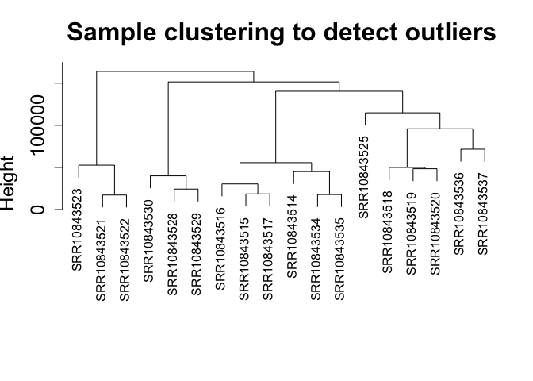

*Added to clusters information regarding traits of data set*

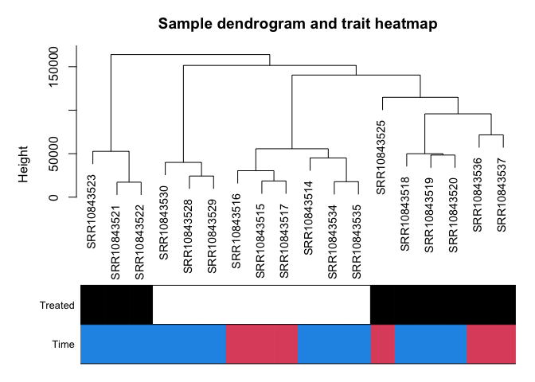

*In this case we will use soft threshold in power 12*

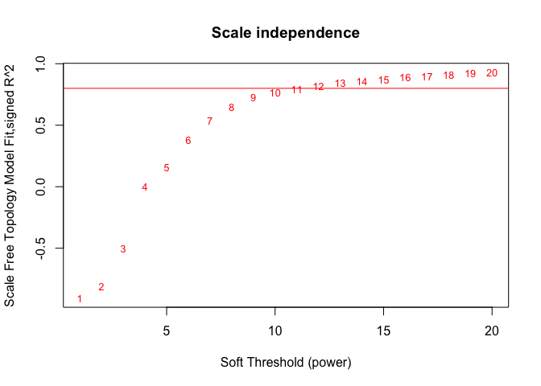

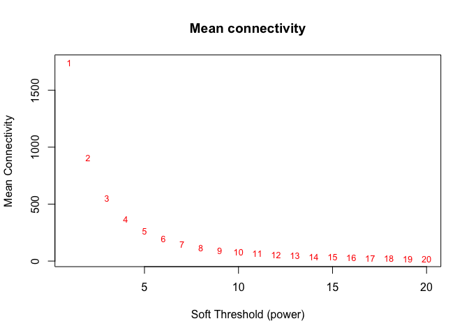

*Module clustering dendrogram*

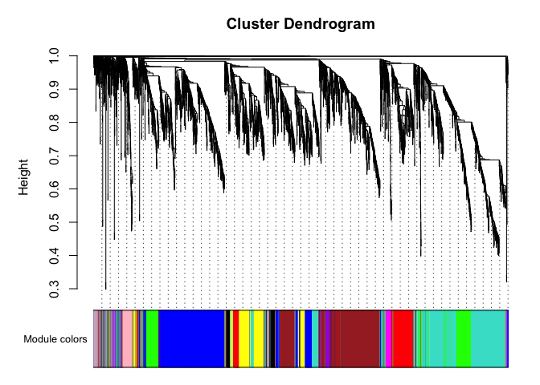

*Significance of modules and their correlation with traits using Spearman’s correlation, we will count that resulta are significant if the are >0.7*

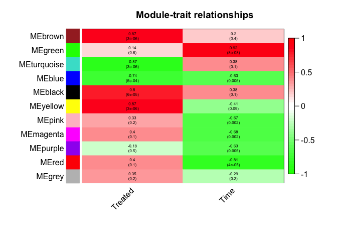

*In our analysis we have five modules that are significant regarding treatment: brown, turquoise, blue, black, yellow; and two regarding time green and red*

*Plot that reveals relationships between eigengenes and traits*

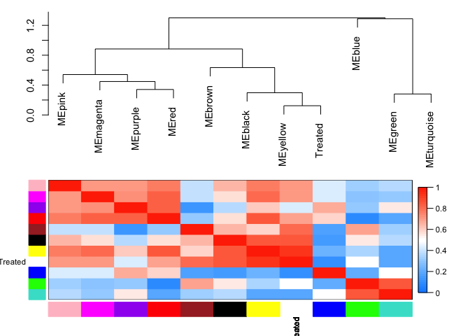

*In this part we perform KEGG enrichment analysis of modules of interest*

*First let’s take a look on modules that were sighnificant in relation towards novobiocin treatment*

*Module 1*

|  | Description | GeneRatio | BgRatio | pvalue | p.adjust |
| --- | --- | --- | --- | --- | --- |
| seo00010 | Glycolysis / Gluconeogenesis | 21/392 | 43/1749 | 0.0001021 | 0.0079611 |
| seo00860 | Porphyrin metabolism | 18/392 | 37/1749 | 0.0003452 | 0.0119826 |
| seo00340 | Histidine metabolism | 8/392 | 11/1749 | 0.0005172 | 0.0119826 |
| seo00520 | Amino sugar and nucleotide sugar metabolism | 23/392 | 54/1749 | 0.0006145 | 0.0119826 |
| seo01120 | Microbial metabolism in diverse environments | 83/392 | 276/1749 | 0.0007705 | 0.0120200 |
| seo02010 | ABC transporters | 56/392 | 174/1749 | 0.0011150 | 0.0144954 |

*Module 2*

|  | ID | Description | GeneRatio | BgRatio | pvalue | p.adjust | qvalue | geneID | Count |
| --- | --- | --- | --- | --- | --- | --- | --- | --- | --- |
| seo02020 | seo02020 | Two-component system | 14/43 | 189/1749 | 0.0000848 | 0.002283 | 0.0020931 | STM14_0249/STM14_1342/STM14_1409/STM14_1686/STM14_1687/STM14_2265/STM14_2335/STM14_2368/STM14_2626/STM14_3044/STM14_3167/STM14_4217/STM14_4881/STM14_4882 | 14 |
| seo01503 | seo01503 | Cationic antimicrobial peptide (CAMP) resistance | 6/43 | 35/1749 | 0.0001473 | 0.002283 | 0.0020931 | STM14_0249/STM14_1409/STM14_2841/STM14_2842/STM14_4881/STM14_4882 | 6 |

*Module 3*

|  | ID | Description | GeneRatio | BgRatio | pvalue | p.adjust | qvalue | geneID | Count |
| --- | --- | --- | --- | --- | --- | --- | --- | --- | --- |
| seo00540 | seo00540 | Lipopolysaccharide biosynthesis | 16/156 | 40/1749 | 1e-07 | 5.6e-06 | 5.5e-06 | STM14_0625/STM14_0731/STM14_1117/STM14_2735/STM14_4003/STM14_4471/STM14_4474/STM14_4475/STM14_4476/STM14_4477/STM14_4478/STM14_4479/STM14_4480/STM14_4482/STM14_4483/STM14_4484 | 16 |

*Module 4*

|  | ID | Description | GeneRatio | BgRatio | pvalue | p.adjust | qvalue | geneID | Count |
| --- | --- | --- | --- | --- | --- | --- | --- | --- | --- |
| seo00660 | seo00660 | C5-Branched dibasic acid metabolism | 10/255 | 16/1749 | 0.0000131 | 0.0009977 | 0.0008706 | STM14_0131/STM14_0132/STM14_0133/STM14_0385/STM14_0386/STM14_3767/STM14_3768/STM14_3769/STM14_4576/STM14_4577 | 10 |
| seo01210 | seo01210 | 2-Oxocarboxylic acid metabolism | 13/255 | 30/1749 | 0.0001177 | 0.0044718 | 0.0039020 | STM14_0131/STM14_0132/STM14_0133/STM14_0134/STM14_0385/STM14_0386/STM14_4260/STM14_4576/STM14_4577/STM14_4955/STM14_4956/STM14_4957/STM14_5074 | 13 |
| seo02020 | seo02020 | Two-component system | 44/255 | 189/1749 | 0.0004780 | 0.0121099 | 0.0105668 | STM14_0063/STM14_0682/STM14_0725/STM14_0823/STM14_0824/STM14_0825/STM14_1497/STM14_1677/STM14_1680/STM14_1966/STM14_2168/STM14_2331/STM14_2332/STM14_2333/STM14_2334/STM14_2365/STM14_2374/STM14_2613/ST… | 44 |

*Module 5*

|  | ID | Description | GeneRatio | BgRatio | pvalue | p.adjust | qvalue | geneID | Count |
| --- | --- | --- | --- | --- | --- | --- | --- | --- | --- |
| seo00970 | seo00970 | Aminoacyl-tRNA biosynthesis | 49/429 | 109/1749 | 1.2e-06 | 7.56e-05 | 7.56e-05 | STM14_0311/STM14_0784/STM14_0785/STM14_0786/STM14_0787/STM14_0788/STM14_0789/STM14_0790/STM14_0874/STM14_0875/STM14_0876/STM14_0877/STM14_0878/STM14_1088/STM14_1231/STM14_1132/STM14_1624/STM14_1720/ST… | 49 |
| seo03010 | seo03010 | Ribosome | 38/429 | 78/1749 | 1.8e-06 | 7.56e-05 | 7.56e-05 | STM14_1110/STM14_1621/STM14_1622/STM14_3276/STM14_3279/STM14_4117/STM14_4119/STM14_4120/STM14_4121/STM14_4122/STM14_4124/STM14_4125/STM14_4126/STM14_4127/STM14_4128/STM14_4129/STM14_4130/STM14_4131/ST… | 38 |

*And now we will take a look on modules related to time*

*Module 1*

|  | Description | GeneRatio | BgRatio | pvalue | p.adjust |
| --- | --- | --- | --- | --- | --- |
| seo04122 | Sulfur relay system | 9/158 | 18/1749 | 0.0000077 | 0.0005369 |
| seo03010 | Ribosome | 18/158 | 78/1749 | 0.0001096 | 0.0038356 |
| seo00541 | O-Antigen nucleotide sugar biosynthesis | 9/158 | 27/1749 | 0.0003607 | 0.0072951 |
| seo01240 | Biosynthesis of cofactors | 27/158 | 156/1749 | 0.0004169 | 0.0072951 |
| seo00521 | Streptomycin biosynthesis | 5/158 | 10/1749 | 0.0009800 | 0.0137203 |
| seo01250 | Biosynthesis of nucleotide sugars | 11/158 | 50/1749 | 0.0038337 | 0.0447269 |

*Module 2*

|  | ID | Description | GeneRatio | BgRatio | pvalue | p.adjust | qvalue | geneID | Count |
| --- | --- | --- | --- | --- | --- | --- | --- | --- | --- |
| seo00920 | seo00920 | Sulfur metabolism | 14/153 | 38/1749 | 0.0000013 | 0.0000864 | 0.0000785 | STM14_2985/STM14_2999/STM14_3000/STM14_3001/STM14_3002/STM14_3127/STM14_3537/STM14_3538/STM14_3539/STM14_3551/STM14_3553/STM14_4887/STM14_5178/STM14_5179 | 14 |
| seo00310 | seo00310 | Lysine degradation | 7/153 | 16/1749 | 0.0001994 | 0.0065810 | 0.0059827 | STM14_2937/STM14_3365/STM14_3366/STM14_3367/STM14_3368/STM14_3896/STM14_5430 | 7 |
| seo00330 | seo00330 | Arginine and proline metabolism | 8/153 | 22/1749 | 0.0003164 | 0.0069616 | 0.0063287 | STM14_0818/STM14_1582/STM14_1583/STM14_1584/STM14_1585/STM14_1586/STM14_3781/STM14_3896 | 8 |
| seo00564 | seo00564 | Glycerophospholipid metabolism | 9/153 | 29/1749 | 0.0005161 | 0.0085155 | 0.0077413 | STM14_2363/STM14_2817/STM14_2819/STM14_2820/STM14_2821/STM14_3015/STM14_3016/STM14_4279/STM14_3883 | 9 |
| seo00350 | seo00350 | Tyrosine metabolism | 7/153 | 21/1749 | 0.0013902 | 0.0173938 | 0.0158126 | STM14_1250/STM14_1251/STM14_1247/STM14_2567/STM14_2684/STM14_3367/STM14_5430 | 7 |
| seo01120 | seo01120 | Microbial metabolism in diverse environments | 38/153 | 276/1749 | 0.0015813 | 0.0173938 | 0.0158126 | STM14_0004/STM14_0613/STM14_1250/STM14_1251/STM14_1247/STM14_1610/STM14_2129/STM14_2684/STM14_2937/STM14_2985/STM14_3033/STM14_3034/STM14_3052/STM14_3127/STM14_3365/STM14_3366/STM14_3367/STM14_3368/ST… | 38 |

*Now we will perform visualization of involved KEGG paths and you will find results in your browser*

*KEGG analysis of treated hubs*

|  | ID | Description | GeneRatio | BgRatio | pvalue | p.adjust | qvalue | geneID | Count |
| --- | --- | --- | --- | --- | --- | --- | --- | --- | --- |
| seo00660 | seo00660 | C5-Branched dibasic acid metabolism | 7/26 | 16/1749 | 0.0000000 | 0.0000000 | 0.0000000 | STM14_0131/STM14_0132/STM14_0133/STM14_0385/STM14_3767/STM14_4576/STM14_4577 | 7 |
| seo01210 | seo01210 | 2-Oxocarboxylic acid metabolism | 8/26 | 30/1749 | 0.0000000 | 0.0000000 | 0.0000000 | STM14_0131/STM14_0132/STM14_0133/STM14_0134/STM14_0385/STM14_4576/STM14_4577/STM14_4956 | 8 |
| seo00290 | seo00290 | Valine, leucine and isoleucine biosynthesis | 7/26 | 20/1749 | 0.0000000 | 0.0000000 | 0.0000000 | STM14_0131/STM14_0132/STM14_0133/STM14_0134/STM14_0385/STM14_4576/STM14_4577 | 7 |
| seo01230 | seo01230 | Biosynthesis of amino acids | 8/26 | 129/1749 | 0.0003549 | 0.0026616 | 0.0021480 | STM14_0131/STM14_0132/STM14_0133/STM14_0134/STM14_0385/STM14_4576/STM14_4577/STM14_4956 | 8 |
| seo00770 | seo00770 | Pantothenate and CoA biosynthesis | 3/26 | 25/1749 | 0.0054024 | 0.0324146 | 0.0261591 | STM14_3153/STM14_4576/STM14_4577 | 3 |

|  | ID | Description | GeneRatio | BgRatio | pvalue | p.adjust | qvalue | geneID | Count |
| --- | --- | --- | --- | --- | --- | --- | --- | --- | --- |
| seo02020 | seo02020 | Two-component system | 8/8 | 189/1749 | 0 | 0 | 0 | STM14_0249/STM14_1686/STM14_1687/STM14_2265/STM14_2626/STM14_3044/STM14_3167/STM14_4217 | 8 |

|  | ID | Description | GeneRatio | BgRatio | pvalue | p.adjust | qvalue | geneID | Count |
| --- | --- | --- | --- | --- | --- | --- | --- | --- | --- |
| seo00540 | seo00540 | Lipopolysaccharide biosynthesis | 13/38 | 40/1749 | 0.0000000 | 0.0000000 | 0.0000000 | STM14_0731/STM14_2735/STM14_4004/STM14_4471/STM14_4475/STM14_4476/STM14_4477/STM14_4478/STM14_4479/STM14_4480/STM14_4482/STM14_4483/STM14_4484 | 13 |
| seo03060 | seo03060 | Protein export | 4/38 | 19/1749 | 0.0005819 | 0.0084380 | 0.0070444 | STM14_3162/STM14_4299/STM14_4779/STM14_4780 | 4 |
| seo00061 | seo00061 | Fatty acid biosynthesis | 3/38 | 13/1749 | 0.0023303 | 0.0225263 | 0.0188059 | STM14_1366/STM14_1367/STM14_2927 | 3 |
| seo00740 | seo00740 | Riboflavin metabolism | 3/38 | 17/1749 | 0.0052170 | 0.0378231 | 0.0315765 | STM14_0493/STM14_2069/STM14_4786 | 3 |
| seo01212 | seo01212 | Fatty acid metabolism | 3/38 | 20/1749 | 0.0083610 | 0.0484937 | 0.0404848 | STM14_1366/STM14_1367/STM14_2927 | 3 |

|  | ID | Description | GeneRatio | BgRatio | pvalue | p.adjust | qvalue | geneID | Count |
| --- | --- | --- | --- | --- | --- | --- | --- | --- | --- |
| seo00620 | seo00620 | Pyruvate metabolism | 15/122 | 61/1749 | 0.0000087 | 0.0005146 | 0.0004315 | STM14_0183/STM14_0184/STM14_1099/STM14_1733/STM14_1889/STM14_1891/STM14_2672/STM14_4215/STM14_4052/STM14_4438/STM14_5220/STM14_5221/STM14_5222/STM14_5223/STM14_5383 | 15 |
| seo00020 | seo00020 | Citrate cycle (TCA cycle) | 9/122 | 29/1749 | 0.0000887 | 0.0024940 | 0.0020913 | STM14_0183/STM14_0184/STM14_2070/STM14_4215/STM14_4052/STM14_5220/STM14_5221/STM14_5222/STM14_5223 | 9 |
| seo01120 | seo01120 | Microbial metabolism in diverse environments | 35/122 | 276/1749 | 0.0001268 | 0.0024940 | 0.0020913 | STM14_0183/STM14_0184/STM14_0276/STM14_0616/STM14_0911/STM14_1025/STM14_1250/STM14_1252/STM14_1099/STM14_1891/STM14_1934/STM14_1905/STM14_1906/STM14_1908/STM14_2070/STM14_2170/STM14_2289/STM14_2642/ST… | 35 |
| seo02010 | seo02010 | ABC transporters | 24/122 | 174/1749 | 0.0005510 | 0.0081267 | 0.0068145 | STM14_0770/STM14_0771/STM14_992/STM14_993/STM14_962/STM14_1031/STM14_1042/STM14_1629/STM14_1802/STM14_1803/STM14_1804/STM14_2106/STM14_2107/STM14_2108/STM14_2109/STM14_2110/STM14_3299/STM14_4280/STM14… | 24 |
| seo01200 | seo01200 | Carbon metabolism | 17/122 | 113/1749 | 0.0014885 | 0.0159378 | 0.0133644 | STM14_0183/STM14_0184/STM14_0911/STM14_1600/STM14_1889/STM14_2070/STM14_2170/STM14_2289/STM14_2642/STM14_3701/STM14_4215/STM14_4052/STM14_5075/STM14_5220/STM14_5221/STM14_5222/STM14_5223 | 17 |
| seo01501 | seo01501 | beta-Lactam resistance | 6/122 | 20/1749 | 0.0017546 | 0.0159378 | 0.0133644 | STM14_1130/STM14_2106/STM14_2107/STM14_2108/STM14_2109/STM14_2110 | 6 |

*Now we will save pathways of interest based on WGCNA analysis related to treatment with novobiocin*

```
## [1] "STM14_0249/STM14_1686/STM14_1687/STM14_2265/STM14_2626/STM14_3044/STM14_3167/STM14_4217"
```

```
## [1] "STM14_0131/STM14_0132/STM14_0133/STM14_0385/STM14_3767/STM14_4576/STM14_4577"
```

```
## [1] "STM14_0131/STM14_0132/STM14_0133/STM14_0134/STM14_0385/STM14_4576/STM14_4577"
```

```
## [1] "STM14_0770/STM14_0771/STM14_992/STM14_993/STM14_962/STM14_1031/STM14_1042/STM14_1629/STM14_1802/STM14_1803/STM14_1804/STM14_2106/STM14_2107/STM14_2108/STM14_2109/STM14_2110/STM14_3299/STM14_4280/STM14_4281/STM14_4370/STM14_4371/STM14_4372/STM14_5122/STM14_4902"
```

*Visualisation of modules eigenes*

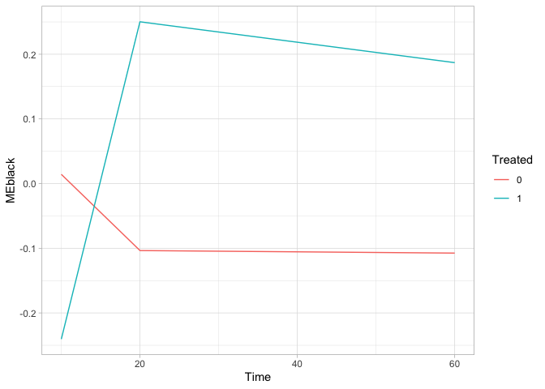

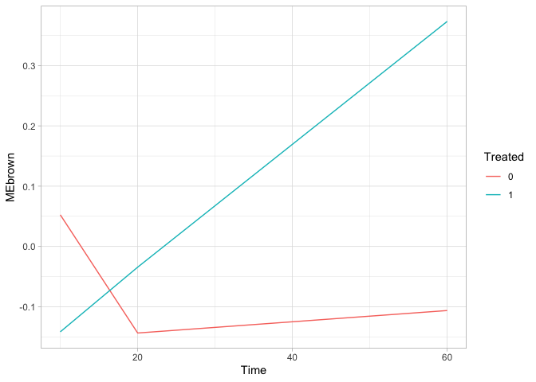

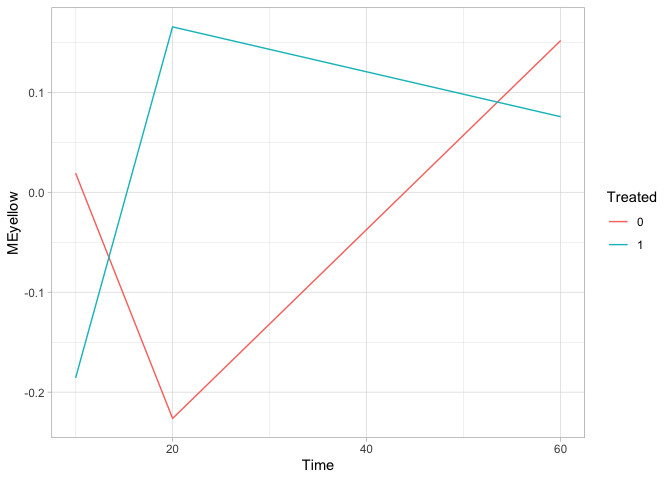

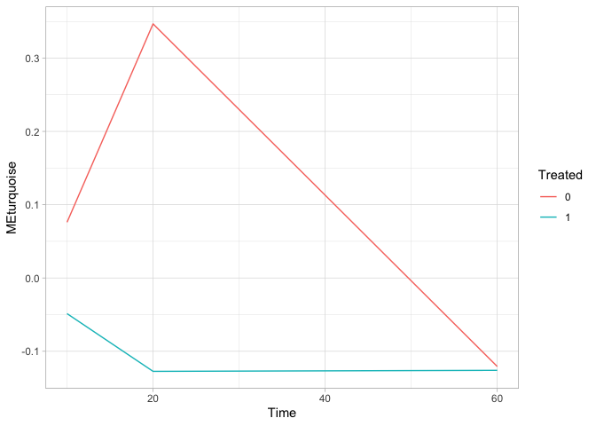

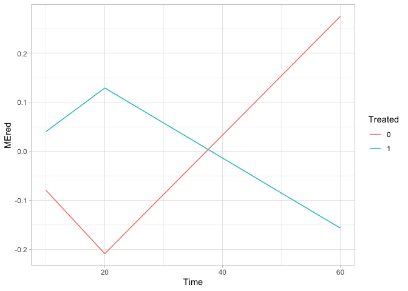

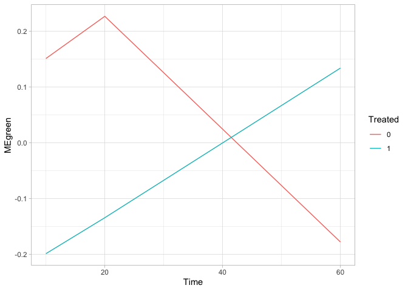

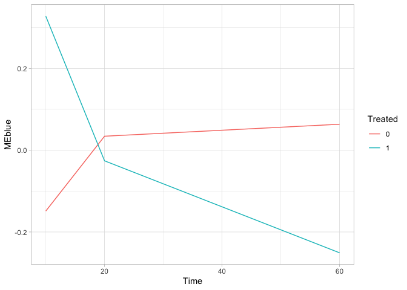

*Visualisation of pathways’genes by their PC1*

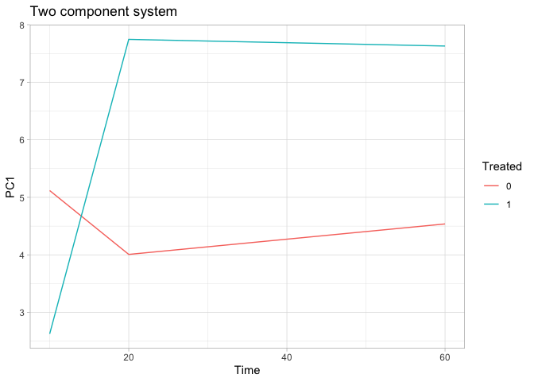

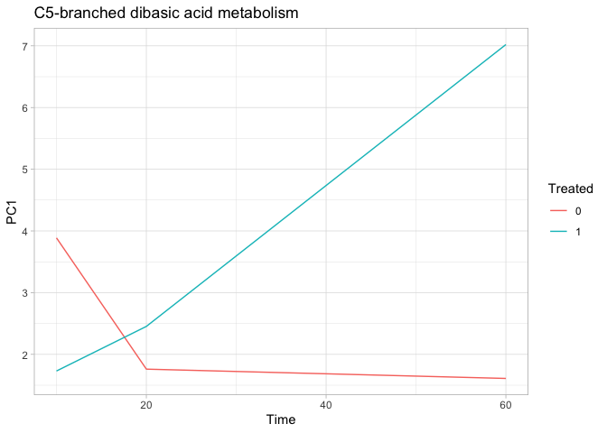

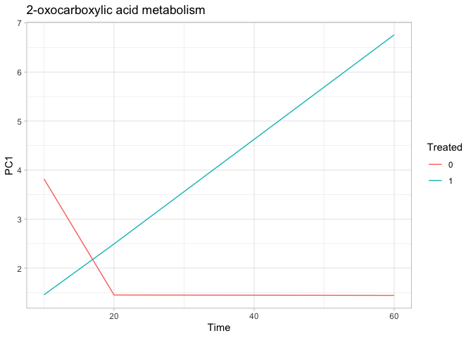

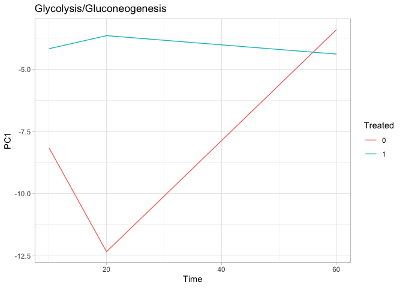